# Cointalk text analysis with tidytext

ed

4/2/2019

(updated 5/5/2019 with new episodes)  
(updated 5/6/2019 to fix some mistakes)

Here is a analysis of sentiment in [Cointalk](https://medium.com/s/cointalk), a podcast about the world of bitcoin and crypto currencies, “The official podcast of Bitcoin crashes Hosted by Aaron Lammer and Jay Caspian Kang.” It’s a great show - if you haven’t listened to it I’d recommend that you check it out.

I took all the Cointalk episodes that have transcriptions and ran them through some sentiment analysis. Looking at the transcripts, we can see who is more positive , who is more negative, and how that changes over time.

I figured that a podcast about bitcoin would have a lot of swings in sentiment over time so I thought it’d be a good text to analyze. Also, the transcripts are available for free, which makes it easy to scrape and analyze. I joined medium to support the podcast.

I followed a lot of the instruction from [Text mining with R](https://www.tidytextmining.com/) by Juila Silge and David Robinson. If you want to see the R code in the markdown file, follow this [link here](https://github.com/edeo/cointalk/blob/master/index.Rmd) .

For more information on the sentiments datasets, click [here](https://www.tidytextmining.com/sentiment.html#the-sentiments-dataset) .

Now we have a table with “name”,“linenumber”,“episode”,“word”.

```r
head(tidy_conversation_main)
```

```
## # A tibble: 6 x 4
##   name        linenumber episode                                     word
##   <chr>            <int> <chr>                                       <chr>
## 1 Aaron Lamm…          1 Episode #2: Korean Crypto-Mania and the Ki… coin
## 2 Aaron Lamm…          1 Episode #2: Korean Crypto-Mania and the Ki… talk
## 3 Aaron Lamm…          1 Episode #2: Korean Crypto-Mania and the Ki… weeke…
## 4 Jay Kang             2 Episode #2: Korean Crypto-Mania and the Ki… bad
## 5 Aaron Lamm…          3 Episode #2: Korean Crypto-Mania and the Ki… pretty
## 6 Aaron Lamm…          3 Episode #2: Korean Crypto-Mania and the Ki… weeke…
```

I join three sentiment tables to that table, one from Bing, one from Afinn, and one from NRC.

We can see the total number of non-stop words Aaron and Jay have used:

```r
tidy_conversation_main %>% group_by(name) %>% tally()
```

```
## # A tibble: 2 x 2
##   name      n
##   <chr> <int>
## 1 Aaron 95174
## 2 Jay   67041
```

Please note that I had to take the word ‘grin’ out of the analysis, since it is refering to a coin, and not to them grinning all the time.

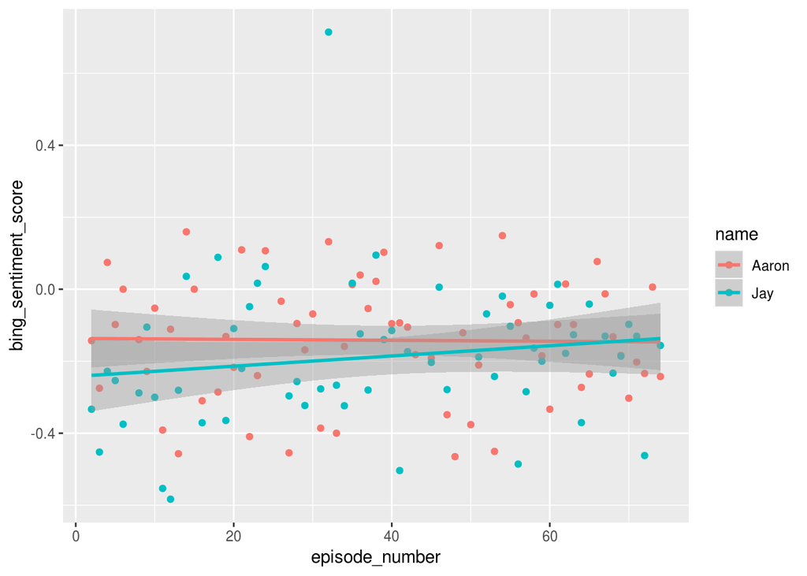

It looks like Aaron starts out more positive than Jay, but over time the two seem to start to converage.

afinn_sentiment_score

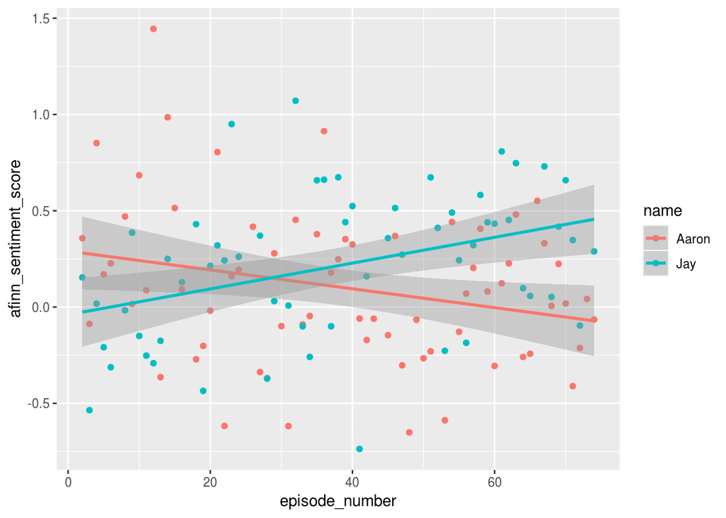

Fear

There’s a lot to be afraid of in the crypto world. This graph uses the NRC sentiment table to show the percentage of fear words over time.

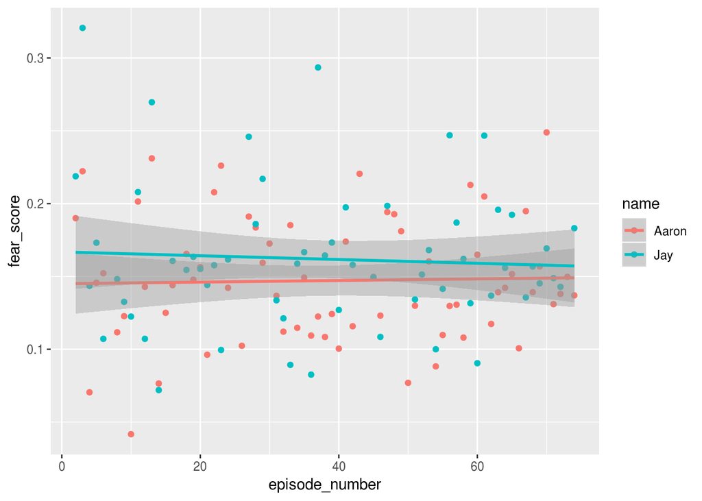

Looks like Aaron has catching up to Jay.

Joy

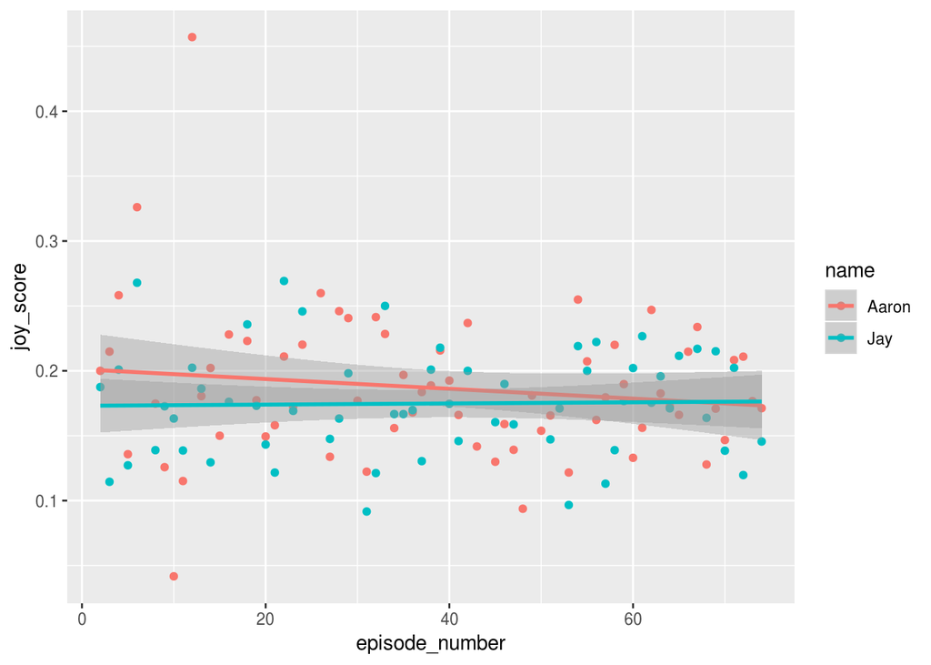

Looks like they converge on joy.

Anger

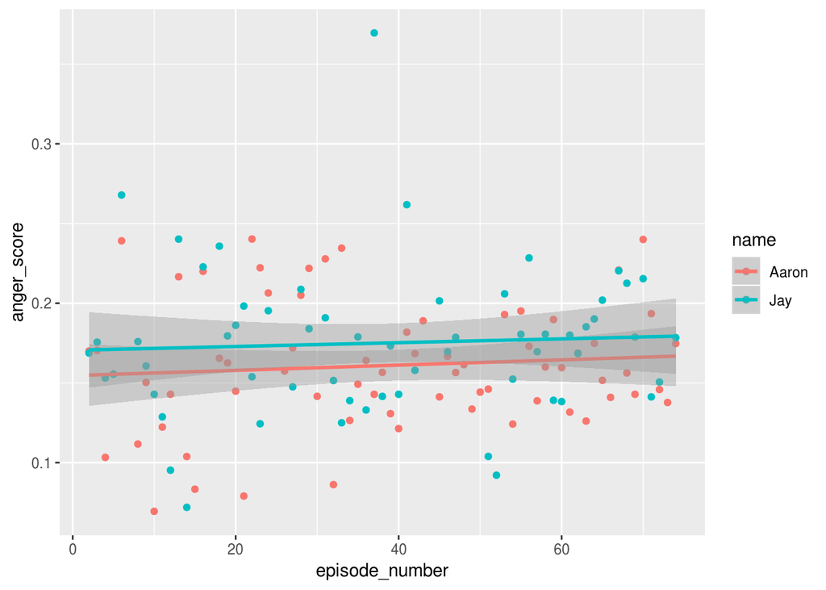

Jay’s angry, but Aaron’s catching up.

Next steps :

Tf/idf  
LDA  
Adding more documents - Breakermag, chain letter from MIT  
Ngram : looking at ngram with ‘pretty’ to see if it ends up more with “pretty good”, “pretty bad”, or something like “this new coin company is pretty sleazy”. This might throw things off since in the bing sentiment table it is coded as positive.

```r
tidy_conversation_main %>% filter(word=='pretty') %>% group_by(name) %>% tally()
```

```
## # A tibble: 2 x 2
##   name      n
##   <chr> <int>
## 1 Aaron   296
## 2 Jay     143
```